# Отчет по лабораторной работе №3

Операционные системы

Бельчуг Александр Константинович

# Цель работы

Цель данной лабораторной работы - научиться оформлять отчёты с помощью легковесного языка разметки Markdown.

# Задание

1. Сделайте отчёт по предыдущей лабораторной работе в формате Markdown.
2. В качестве отчёта предоставляются отчёты в 3 форматах: pdf, docx и md (в архиве, поскольку он должен содержать скриншоты, Makefile и т.д.)

# Теоретическое введение

Markdown — облегчённый язык разметки, созданный с целью обозначения форматирования в простом тексте, с максимальным сохранением его читаемости человеком, и пригодный для машинного преобразования в языки для продвинутых публикаций.

# Выполнение лабораторной работы

Повторение тоже операций только с каталогом report (можно открыть с помощью редактора Kwrite, в нем оказалось удобнее работать) (рис. @fig:003).

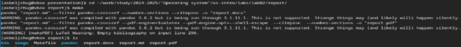

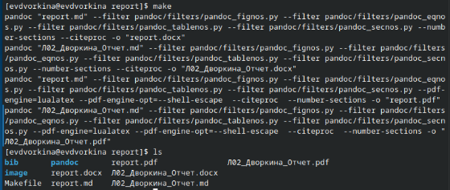

Далее отправила созданные и скомпилированные файлы на глобальный репозиторий (рис. @fig:005).

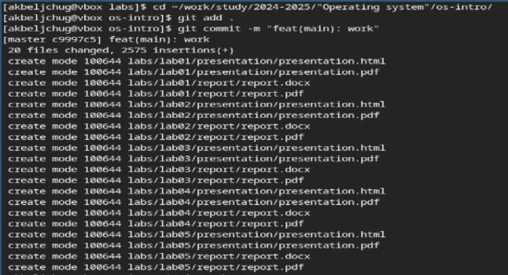

Последнее действие в отправке с помощью компанды git push(рис. @fig:006).

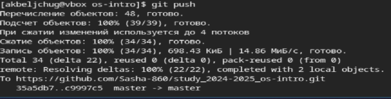

Последнее действие в отправке с помощью компанды git push

Отправка файлов на Git (рис. @fig:006).

# Выводы

При выполнении данной лабораторной работы я научилась оформлять отчеты с помощью легковесного языка разметки Markdown.